# PROJEKTE

# Plotesime

Në këtë projekt do të përdor modelin Hybrid (kombinim i ARIMA, ETS dhe NNAR) për parashikimin e serisë së lejeve të ndërtimit. Zgjedhja e Hybrid bazohet në idenë se asnjë model i vetëm nuk kap të gjitha aspektet e serisë: struktura lineare, trendi/sezonaliteti dhe luhatjet jo-lineare. Duke i bashkuar, synohet një parashikim më i qëndrueshëm dhe i besueshëm.

## Modeli HYBRID

```r
library(forecast)
library(forecastHybrid)
# seria është myts
n <- length(myts)

# Ndarja: lëmë 4 vlerat e fundit për test
train <- window(myts, end = c(time(myts)[n-4]))
test  <- window(myts, start = c(time(myts)[n-3]))

# Ndërtimi i modelit Hybrid mbi train
fit_hybrid <- hybridModel(train, models = "aen")
```

```
## Fitting the auto.arima model
```

```
## Fitting the ets model
```

```
## Fitting the nnetar model
```

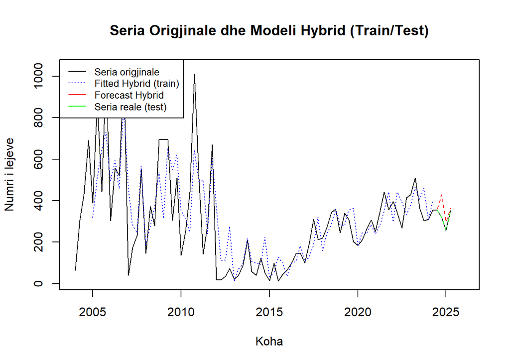

```r
# Parashikimi për gjatësi sa test
h <- length(test)
fc_hybrid <- forecast(fit_hybrid, h = h)

# Grafik: train + test + forecast Hybrid
plot(myts,
     main = "Seria Origjinale dhe Modeli Hybrid (Train/Test)",
     xlab = "Koha",
     ylab = "Numri i lejeve",
     col = "black",
     xlim = c(start(myts)[1], end(fc_hybrid$mean)[1] + 1))

# Fitted values mbi train
lines(ts(fitted(fit_hybrid), start = start(train), frequency = frequency(train)),
      col = "blue", lty = 3)

# Forecast mbi test
lines(fc_hybrid$mean, col = "red", lty =2)

# Seria reale e testit (për krahasim)
lines(test, col = "green", lty = 2)

# Legjenda
legend("topleft",
       legend = c("Seria origjinale", "Fitted Hybrid (train)", "Forecast Hybrid", "Seria reale (test)"),
       col = c("black", "blue", "red", "green"),
       lty = c(1, 3, 1, 1),
       cex = 0.8)
```

```r
library(forecastHybrid)

# Modeli Hybrid
fit_hybrid <- hybridModel(myts, models = "aen")  # ARIMA + ETS + NNAR
```

```
## Fitting the auto.arima model
```

```
## Fitting the ets model
```

```
## Fitting the nnetar model
```

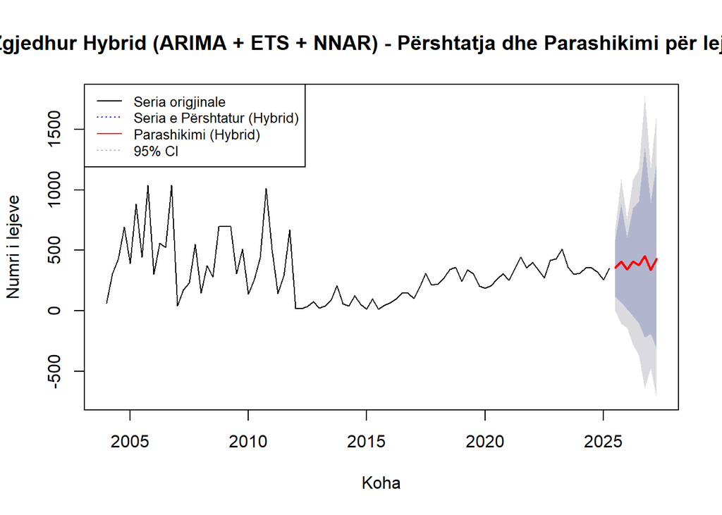

```r
# Parashikimi për 8 tremujorë
h_test <- 8
forecast_hybrid <- forecast(fit_hybrid, h = h_test)

# Grafik i serisë origjinale dhe parashikimit Hybrid
plot(forecast_hybrid,
     main = "Modeli i Zgjedhur Hybrid (ARIMA + ETS + NNAR) - Përshtatja dhe Parashikimi për lejet e ndërtimit",
     xlab = "Koha",
     ylab = "Numri i lejeve",
     col = "blue",
     fcol = "red",
     flty = 1)

# serinë origjinale
lines(myts, col = "black", lty = 1)

#  vlerat e përshtatura (fitted)
lines(fitted(fit_hybrid), col = "blue", lty = 3)

#  intervalet e besimit
lines(forecast_hybrid$lower[,2], col = "darkgray", lty = 3)
lines(forecast_hybrid$upper[,2], col = "darkgray", lty = 3)

# Legjenda
legend("topleft",
       legend = c("Seria origjinale", "Seria e Përshtatur (Hybrid)", "Parashikimi (Hybrid)", "95% CI"),
       col = c("black", "blue", "red", "darkgray"),
       lty = c(1, 3, 1, 3),
       cex = 0.8)
```

Modeli ka treguar një përshtatje të mirë me të dhënat historike dhe një parashikim të qëndrueshëm, duke ruajtur ritmin e serisë pa luhatje të papritura. Kjo e bën Hybrid një zgjedhje të përshtatshme për seri me kompleksitet të moderuar dhe sezonalitet të pranishëm. Parashikimin nga Hybrid (vija e kuqe),zgjatja e serisë në të ardhmen për 8 tremujorë. Kjo linjë tregon pritshmërinë e modelit për ecurinë e lejeve në periudhën pas trajnimit.